# Exploit DataOrigin in VOTable

G.Landais (CDS), Feb-2025

Note: https://www.ivoa.net/documents/DataOrigin/

DataOrigin goal: list of metadata that describes both query and datasets basic provenance.

- Semantic based on Registry (VOResource) described in RDF documents
- Basic Provenance can be serialized in VOTable result with simple "INFO" tag.

Example: https://vizier.cds.unistra.fr/viz-bin/conesearch/J/MNRAS/473/4130?RA=10.7039167&DEC=41.25666&SR=0.1

## Extract basic information from a VizieR query

Library used in this notebook:

- module astropy.io.votable
- module (**pull request**) astropy.io.votable.dataorigin https://github.com/gilleslandais/astropy/

[figure not shown]

```python
import astropy.io.votable
import astropy.io.votable.dataorigin as dataorigin
```

Query VizieR catalogue (using CDS protocol ASU).

Catalogue: J/AJ/164/20 : RGB radial velocities in M31 northeast shelf fields (Escala+, 2022)

```python
aj_votable = astropy.io.votable.parse("https://vizier.cds.unistra.fr/viz-bin/votable?-source=J/AJ/164/20/table2")
aj_votable.get_table_by_index(0).to_table()[:10]
```

*Table length=10*

| recno int32 | ID int32 | RAJ2000 str11 | DEJ2000 str11 | Vmag mag float32 | Imag mag float32 | e_Vmag mag float32 | e_Imag mag float32 | RVel km / s float32 | e_RVel km / s float32 | Simbad str6 |
| --- | --- | --- | --- | --- | --- | --- | --- | --- | --- | --- |
| 1 | 133576 | 00 52 36.06 | +42 08 14.3 | 23.17 | 20.72 | 0.03 | 0.03 | -343.9 | 3.6 | Simbad |
| 2 | 137351 | 00 52 36.24 | +42 08 57.0 | 22.81 | 21.17 | 0.02 | 0.02 | -346.0 | 4.0 | Simbad |
| 3 | 137797 | 00 52 36.80 | +42 09 04.3 | 23.75 | 22.17 | 0.04 | 0.03 | -210.1 | 8.9 | Simbad |
| 4 | 140180 | 00 52 25.13 | +42 09 28.9 | 23.44 | 21.60 | 0.05 | 0.04 | -306.0 | 5.5 | Simbad |
| 5 | 140853 | 00 52 28.23 | +42 09 37.8 | 22.62 | 21.45 | 0.04 | 0.05 | -270.6 | 6.6 | Simbad |
| 6 | 141301 | 00 52 33.86 | +42 09 45.4 | 23.63 | 21.29 | 0.07 | 0.06 | -252.1 | 3.7 | Simbad |
| 7 | 142012 | 00 52 30.51 | +42 09 54.3 | 23.60 | 21.91 | 0.05 | 0.03 | -372.1 | 5.8 | Simbad |
| 8 | 143936 | 00 52 41.88 | +42 10 15.7 | 22.43 | 20.99 | 0.01 | 0.01 | -284.3 | 3.5 | Simbad |
| 9 | 145261 | 00 52 37.33 | +42 10 30.0 | 22.98 | 21.53 | 0.02 | 0.02 | -298.4 | 7.3 | Simbad |
| 10 | 146884 | 00 52 27.56 | +42 10 49.0 | 23.84 | 20.84 | 0.07 | 0.05 | -325.5 | 3.2 | Simbad |

```python
aj_dataorigin = dataorigin.extract_data_origin(aj_votable)
print(aj_dataorigin)
```

```
publisher: CDS
server_software: 7.4.6
service_protocol: ASU
request: https://vizier.cds.unistra.fr/viz-bin/votable?-source=J/AJ/164/20/table2
request_date: 2025-03-25T21:53:00
contact: cds-question@unistra.fr

ivoid: ivo://cds.vizier/j/aj/164/20
citation: doi:10.26093/cds/vizier.51640020
reference_url: https://cdsarc.cds.unistra.fr/viz-bin/cat/J/AJ/164/20
rights_uri: https://cds.unistra.fr/vizier-org/licences_vizier.html
creator: Escala I.
editor: Astronomical Journal (AAS)
cites: bibcode:2022AJ....164...20E
original_date: 2022
publication_date: 2024-11-12
```

##### The API separates (basic) Provenance and Query informations

```python
# get query information (reproducibility)
print("Query:")
print(aj_dataorigin.query)
# Get Basic Provenance
print("\nOrigin:")
print(aj_dataorigin.origin[0])
```

```
Query:
publisher: CDS
server_software: 7.4.6
service_protocol: ASU
request: https://vizier.cds.unistra.fr/viz-bin/votable?-source=J/AJ/164/20/table2
request_date: 2025-03-25T21:53:00
contact: cds-question@unistra.fr

Origin:
ivoid: ivo://cds.vizier/j/aj/164/20
citation: doi:10.26093/cds/vizier.51640020
reference_url: https://cdsarc.cds.unistra.fr/viz-bin/cat/J/AJ/164/20
rights_uri: https://cds.unistra.fr/vizier-org/licences_vizier.html
creator: Escala I.
editor: Astronomical Journal (AAS)
cites: bibcode:2022AJ....164...20E
original_date: 2022
publication_date: 2024-11-12
```

**Query VOTable containing 2 resources** Query 2 catalogues having data in M31

- J/AJ/164/20: RGB radial velocities in M31 northeast shelf fields (Escala+, 2022)
- J/MNRAS/473/4130: A SITELLE view of M31's central region. I Calibrations and radial velocity catalogue of nearly 800 emission-line point-like sources. (2018)

```python
m31_votables = astropy.io.votable.parse("https://vizier.cds.unistra.fr/viz-bin/votable?-source=J/AJ/164/20/table2,J/MNRAS/473/4130")
```

```python
# Table J/AJ/164/20/table2
m31_votables.get_table_by_index(0).to_table()[:5]
```

*Table length=5*

| recno int32 | ID int32 | RAJ2000 str11 | DEJ2000 str11 | Vmag mag float32 | Imag mag float32 | e_Vmag mag float32 | e_Imag mag float32 | RVel km / s float32 | e_RVel km / s float32 | Simbad str6 |
| --- | --- | --- | --- | --- | --- | --- | --- | --- | --- | --- |
| 1 | 133576 | 00 52 36.06 | +42 08 14.3 | 23.17 | 20.72 | 0.03 | 0.03 | -343.9 | 3.6 | Simbad |
| 2 | 137351 | 00 52 36.24 | +42 08 57.0 | 22.81 | 21.17 | 0.02 | 0.02 | -346.0 | 4.0 | Simbad |
| 3 | 137797 | 00 52 36.80 | +42 09 04.3 | 23.75 | 22.17 | 0.04 | 0.03 | -210.1 | 8.9 | Simbad |
| 4 | 140180 | 00 52 25.13 | +42 09 28.9 | 23.44 | 21.60 | 0.05 | 0.04 | -306.0 | 5.5 | Simbad |
| 5 | 140853 | 00 52 28.23 | +42 09 37.8 | 22.62 | 21.45 | 0.04 | 0.05 | -270.6 | 6.6 | Simbad |

```python
# Table J/MNRAS/473/4130
m31_votables.get_table_by_index(1).to_table()[:5]
```

*Table length=5*

| recno int32 | ID str19 | RAJ2000 str11 | DEJ2000 str11 | HRV km / s float32 | e_HRV km / s float32 | ELB km / s float32 | e_ELB km / s float32 | F6563 mW / m2 float32 | e_F6563 mW / m2 float32 | l_F6584 str1 | F6584 mW / m2 float32 | e_F6584 mW / m2 float32 | l_F6716_6731 str1 | F6716_6731 mW / m2 float32 | e_F6716_6731 mW / m2 float32 | IDM2006 int16 | IDH2006 str9 | XmMHa str4 | XmMOIII str4 | Comments str13 | SimbadName str14 |
| --- | --- | --- | --- | --- | --- | --- | --- | --- | --- | --- | --- | --- | --- | --- | --- | --- | --- | --- | --- | --- | --- |
| 1 | S004248.94+411524.0 | 00 42 48.94 | +41 15 24.0 | -563.1 | 2.5 | 25.1 | 1.5 | 3.2e-15 | 2e-16 |  | 8e-16 | 1.1e-16 | < | 3e-16 | -- | 1336 | P62 | Sat. | Sat. |  | [MMD2006] 1336 |
| 2 | S004253.55+411734.3 | 00 42 53.55 | +41 17 34.3 | -443.4 | 2.7 | 30.9 | 1.7 | 2.4e-15 | 1.6e-16 | < | 4.2e-16 | -- | < | 2.4e-16 | -- | 1261 | P29 | Sat. | Sat. |  | [MMD2006] 1261 |
| 3 | S004246.47+411702.7 | 00 42 46.47 | +41 17 02.7 | -349.4 | 2.4 | 29.1 | 1.0 | 4.4e-15 | 2.4e-16 |  | 4.7e-15 | 2.5e-16 | < | 6.9e-16 | -- | 1330 |  | Sat. | Sat. |  | [MMD2006] 1330 |
| 4 | S004231.03+411625.3 | 00 42 31.03 | +41 16 25.3 | -94.0 | 2.4 | 20.1 | 1.4 | 2.8e-15 | 1.6e-16 |  | 5.7e-16 | 7.8e-17 | < | 4.4e-16 | -- | 1151 | P43 | Sat. | Sat. |  | [MMD2006] 1151 |
| 5 | S004249.75+411803.9 | 00 42 49.75 | +41 18 03.9 | -438.3 | 2.4 | 17.2 | 1.6 | 2e-15 | 1.2e-16 |  | 1.7e-15 | 1.1e-16 | < | 5.3e-16 | -- | -- |  | Sat. | Sat. |  |  |

```python
# Data Origin
m31_dataorigin = dataorigin.extract_data_origin(m31_votables)
print(m31_dataorigin)
```

```
publisher: CDS
server_software: 7.4.6
service_protocol: ASU
request: https://vizier.cds.unistra.fr/viz-bin/votable?-source=J/AJ/164/20/table2,J/MNRAS/473/4130
request_date: 2025-03-25T21:55:17
contact: cds-question@unistra.fr

ivoid: ivo://cds.vizier/j/aj/164/20
citation: doi:10.26093/cds/vizier.51640020
reference_url: https://cdsarc.cds.unistra.fr/viz-bin/cat/J/AJ/164/20
rights_uri: https://cds.unistra.fr/vizier-org/licences_vizier.html
creator: Escala I.
editor: Astronomical Journal (AAS)
cites: bibcode:2022AJ....164...20E
original_date: 2022
publication_date: 2024-11-12

ivoid: ivo://cds.vizier/j/mnras/473/4130
citation: doi:10.26093/cds/vizier.74734130
reference_url: https://cdsarc.cds.unistra.fr/viz-bin/cat/J/MNRAS/473/4130
rights_uri: https://cds.unistra.fr/vizier-org/licences_vizier.html
creator: Martin T.B.
cites: bibcode:2018MNRAS.473.4130M
original_date: 2018
publication_date: 2024-08-17
```

**Extract infos**

- get contact
- get DOI(s)
- Make an APA citation

```python
print(f"Contact: {m31_dataorigin.query.contact}")

for origin in m31_dataorigin.origin:
    print(f"\nivoid: {origin.ivoid[0]}, citation={origin.citation[0]}\n")

    # Citation in APA style
    vo_elt = origin.get_votable_element()
    title = vo_elt.description if vo_elt else ""
    print(f"APA: {','.join(origin.creator)} ({origin.publication_date[0]}). {title} [Dataset]. {m31_dataorigin.query.publisher}. {origin.citation[0]}")
```

```
Contact: cds-question@unistra.fr

ivoid: ivo://cds.vizier/j/aj/164/20, citation=doi:10.26093/cds/vizier.51640020

APA: Escala I. (2024-11-12). RGB radial velocities in M31 northeast shelf fields (Escala+, 2022) [Dataset]. CDS. doi:10.26093/cds/vizier.51640020

ivoid: ivo://cds.vizier/j/mnras/473/4130, citation=doi:10.26093/cds/vizier.74734130

APA: Martin T.B. (2024-08-17). M31 center emission-line point-like sources (Martin+, 2018) [Dataset]. CDS. doi:10.26093/cds/vizier.74734130
```

# DataOrigin and Provenance (ProvDM)

Use voprov Python package (M.Sanguillon): https://github.com/sanguillon/voprov

In this part, we will use:

- module astropy.io.votable
- module astropy.io.votable.dataorigin
- pyvo
- voprov
- module dataorigin.provenance : **home-made library not planed to be share yet**

```python
#from dataorigin import provenance
import dataorigin_prov.provenance as provenance
from voprov.visualization.dot import prov_to_dot
from IPython.display import Image
import sys
```

**Extract Provenance from DataOrigin** and print in Turtle (rdf)

```python
pdoc = provenance.extract_prov_from_dataorigin(aj_dataorigin, entity_name="aj_resultset")
pdoc.serialize(sys.stdout, format='rdf', rdf_format='ttl')
#print(pdoc.get_provn())
```

```
@prefix prov: <http://www.w3.org/ns/prov#> .
@prefix rdfs: <http://www.w3.org/2000/01/rdf-schema#> .
@prefix staff: <https://orcid.org/orcid-search/search?searchQuery=> .
@prefix voprov: <http://www.ivoa.net/documents/ProvenanceDM/index.html#> .
@prefix xsd: <http://www.w3.org/2001/XMLSchema#> .

voprov:aj_resultset a voprov:Entity ;
    rdfs:label "votable"^^xsd:string ;
    prov:wasGeneratedBy voprov:Query .

voprov:Query a voprov:Activity ;
    voprov:end_time "2025-03-25T21:53:00"^^xsd:string ;
    prov:isDescribedBy voprov:Query_desc ;
    prov:qualifiedAssociation [ a voprov:Association ;
            voprov:role "publisher"^^xsd:string ] ;
    prov:used <https://ivoa.net/#//cds.vizier/j/aj/164/20> ;
    prov:wasAssociatedWith staff:CDS .

voprov:Query_desc a voprov:ActivityDescription ;
    voprov:description "executed query see url"^^xsd:string ;
    voprov:docurl "https://vizier.cds.unistra.fr/viz-bin/votable?-source=J/AJ/164/20/table2"^^xsd:string ;
    voprov:version "7.4.6"^^xsd:string ;
    prov:name "ASU"^^xsd:string .

<https://ivoa.net/#//cds.vizier/j/aj/164/20> a voprov:Entity ;
    voprov:type "dataset"^^xsd:string ;
    prov:wasAttributedTo <https://orcid.org/orcid-search/search?searchQuery=Escala+I.> .

staff:CDS a voprov:Agent ;
    voprov:email "cds-question@unistra.fr"^^xsd:string .

<https://orcid.org/orcid-search/search?searchQuery=Escala+I.> a voprov:Agent .
```

Make a graph

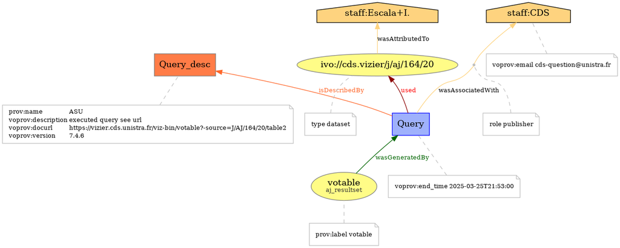

```python
dot = prov_to_dot(pdoc, use_labels=True)
dot.write_png('/tmp/voprov_example.png')
Image('/tmp/voprov_example.png')
```

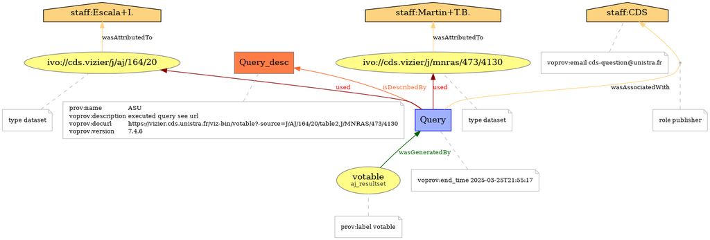

```python
pdoc = provenance.extract_prov_from_dataorigin(m31_dataorigin, entity_name="aj_resultset")
dot = prov_to_dot(pdoc, use_labels=True)
dot.write_png('/tmp/voprov_example.png')
Image('/tmp/voprov_example.png')
```

## Use ProvDM to serialize an ivoa workflow

In the example we will make a conesearch on VizieR (j/aj/164/20) and then reuse the result to query by TAP the GAVO ObsCore table

```python
import pyvo
```

```python
# Make a VizieR conesearch
vizier_resource = pyvo.registry.search(ivoid="ivo://CDS.VizieR/j/aj/164/20")[0]
vizier_conesearch = vizier_resource.get_interface(service_type='conesearch').to_service()
vizier_records = vizier_conesearch.search(pos=(13.1502500, 42.1373), sr=2/60.)
```

**Note:** comptible with pyvo

```python
vizier_dataorigin = dataorigin.extract_data_origin(vizier_records.votable)
print(vizier_dataorigin)
```

```
publisher: CDS
server_software: 7.4.6
service_protocol: ivo://ivoa.net/std/ConeSearch/v1.03
request: https://vizier.cds.unistra.fr/viz-bin/conesearch/J/AJ/164/20/table2?RA=13.15025&DEC=42.1373&SR=0.03333333333333333&VERB=2
request_date: 2025-03-25T22:00:26
contact: cds-question@unistra.fr

ivoid: ivo://cds.vizier/j/aj/164/20
citation: doi:10.26093/cds/vizier.51640020
reference_url: https://cdsarc.cds.unistra.fr/viz-bin/cat/J/AJ/164/20
rights_uri: https://cds.unistra.fr/vizier-org/licences_vizier.html
creator: Escala I.
editor: Astronomical Journal (AAS)
cites: bibcode:2022AJ....164...20E
original_date: 2022
publication_date: 2024-11-12
```

```python
tap_service = pyvo.dal.TAPService("http://dc.g-vo.org/tap")
sql = '''
SELECT TOP 100  *
  FROM ivoa.obscore LEFT JOIN TAP_UPLOAD.vizier
    ON 1=CONTAINS(POINT("_RAJ2000", "_DEJ2000"), CIRCLE(s_ra,s_dec,0.1))
'''
resultset = tap_service.run_sync(uploads={'vizier': vizier_records}, query=sql)
```

```python
resultset_dataorigin = dataorigin.extract_data_origin(resultset.votable)
print(resultset_dataorigin)
```

```
ivoid_service: ivo://org.gavo.dc/tap
publisher: The GAVO DC team
server_software: DaCHS/2.10 twistedWeb/22.4.0
query:  SELECT TOP 100  *    FROM ivoa.obscore LEFT JOIN TAP_UPLOAD.vizier      ON 1=CONTAINS(POINT("_RAJ2000", "_DEJ2000"), CIRCLE(s_ra,s_dec,0.1))
request_date: 2025-03-25T22:01:30Z
contact: gavo@ari.uni-heidelberg.de

ivoid: ivo://org.gavo.dc/__system__/obscore/ObsCore
citation: http://dc.g-vo.org/__system__/tap/run/howtocite,http://dc.g-vo.org/tableinfo/ivoa.ObsCore#ti-citing
reference_url: http://dc.g-vo.org/__system__/tap/run/info,http://dc.g-vo.org/tableinfo/ivoa.ObsCore
creator: GAVO Data Centre
```

Join the 2 graphs.

- make Provenance for the 2 steps (vizier_prov and resulset_prov)
- Update the final Provenance Activity with the result Entity of the first step (vizier conesearch) using *"used"* relation

```python
vizier_prov = provenance.extract_prov_from_dataorigin(vizier_dataorigin, entity_name="vizier_records", activity_name="vizier_conesearch")
resultset_prov = provenance.extract_prov_from_dataorigin(resultset_dataorigin, entity_name="resultset", activity_name="gavo_tap")
provenance.link_prov_activity(prov_final=resultset_prov,
                              prov_used=vizier_prov,
                              id_activity_final="gavo_tap",
                              id_entity_used="vizier_records")
```

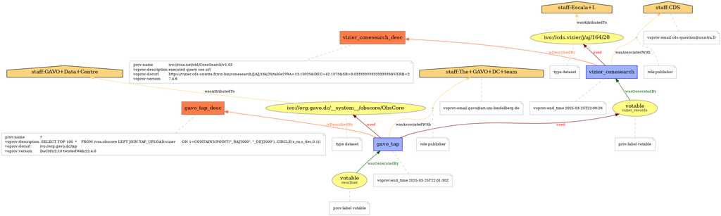

```python
dot = prov_to_dot(resultset_prov, use_labels=True)
dot.write_png('/tmp/voprov_example.png')
Image('/tmp/voprov_example.png')
```

## Limits on for DataOrigin serialisation

Make a TAP uery that crossmatches 2 tables:

- J/AJ/164/20/table2
- I/355/gaiadr3

```python
tap_service = pyvo.dal.TAPService("https://tapvizier.cds.unistra.fr/TAPVizieR/tap")
sql = '''
SELECT TOP 100  *
  FROM "J/AJ/164/20/table2" aj LEFT JOIN "I/355/gaiadr3" as gaia
    ON DISTANCE(POINT('ICRS', aj.RAJ2000, aj.DEJ2000), POINT('ICRS', gaia.RA_ICRS, gaia.DE_ICRS))<5/3600.
'''
xmatch = tap_service.run_sync(query=sql)
```

```python
xmatch
```

```
<DALResultsTable length=100>
recno   ID        RAJ2000       ... e_RAJ2000 e_DEJ2000 RADEcorJ2000
                    deg         ...    mas       mas
int32 int32       float64       ...  float64   float64    float32
----- ------ ------------------ ... --------- --------- ------------
  306 359932 12.451958333333332 ...        --        --           --
  309 375396 12.447166666666664 ...        --        --           --
  314 382592 12.479791666666666 ...        --        --           --
  318 390421  12.48670833333333 ...        --        --           --
  315 383898 12.467749999999999 ...        --        --           --
  341 439818 12.521374999999999 ...        --        --           --
  347 453850 12.531249999999998 ...        --        --           --
  359 470020 12.540291666666665 ...        --        --           --
  362 472882 12.530041666666666 ...        --        --           --
  ...    ...                ... ...       ...       ...          ...
   25 158008 13.217458333333331 ...        --        --           --
   29 161854 13.207333333333331 ...        --        --           --
   38 163964 13.229916666666664 ...        --        --           --
    8 143936 13.174499999999998 ...        --        --           --
   16 151915 13.161499999999998 ...        --        --           --
   19 154525 13.186749999999998 ...        --        --           --
   14 151036 13.142083333333332 ...        --        --           --
   15 151337 13.146083333333332 ...        --        --           --
   20 154782 13.136166666666664 ...        --        --           --
```

```python
xmatch_dataorigin = dataorigin.extract_data_origin(xmatch.votable)
print(xmatch_dataorigin)
```

```
ivoid_service: ivo://CDS.VizieR/TAP
publisher: ivo://CDS
server_software: TAPVizieR-Vollt/1.1.3
service_protocol: ivo://ivoa.net/std/TAP/v1.1
query:  SELECT TOP 100  *    FROM "J/AJ/164/20/table2" aj LEFT JOIN "I/355/gaiadr3" as gaia      ON DISTANCE(POINT('ICRS', aj.RAJ2000, aj.DEJ2000), POINT('ICRS', gaia.RA_ICRS, gaia.DE_ICRS))<5/3600.
request_date: 2025-03-25 23:04:26
contact: cds-question@unistra.fr

ivoid: ivo://CDS.VizieR/J/AJ/164/20,ivo://CDS.VizieR/I/355
reference_url: https://cdsarc.cds.unistra.fr/viz-bin/cat/J/AJ/164/20,https://cdsarc.cds.unistra.fr/viz-bin/cat/I/355
rights_uri: https://cds.unistra.fr/vizier-org/licences_vizier.html,https://cds.unistra.fr/vizier-org/licences_vizier.html
creator: Escala I.,Gaia collaboration
article: 2022AJ....164...20E,2022yCat.1355....0G
publication_date: 2022-11-04 08:10:20+01,2022-06-20 08:37:42+02
```

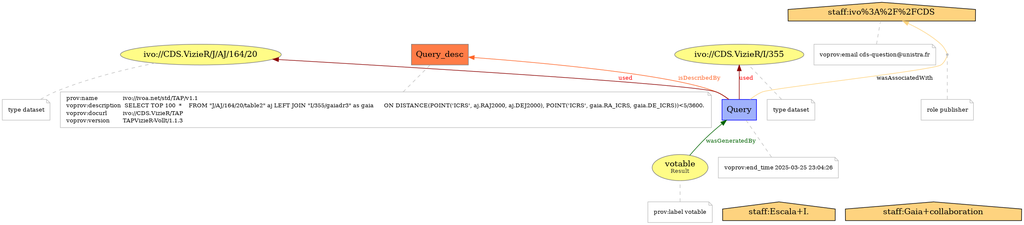

```python
xmatch_prov = provenance.extract_prov_from_dataorigin(xmatch_dataorigin)
dot = prov_to_dot(xmatch_prov, use_labels=True)
dot.write_png('/tmp/voprov_example.png')
Image('/tmp/voprov_example.png')
```

Problem with "INFO" tag to distinguish metadata by resources.

Soon (may be?) a response mivot/Mango

[figure not shown]

### astroquery

No interface available for astroquery yet because astroquery API provides astropy.table and not astropy.io.votable